**[Deep Learning Home Page](https://www.kaggle.com/learn/deep-learning)**

# Intro

You don't directly choose the numbers to go into your convolutions for deep learning... instead the deep learning technique determines what convolutions will be useful from the data (as part of model-training). We'll come back to how the model does that soon.

[figure not shown]

But looking closely at convolutions and how they are applied to your image will improve your intuition for these models, how they work, and how to debug them when they don't work.

**Let's get started.**

# Exercises

We'll use some small utilty functions to visualize raw images and some results of your code. Execute the next cell to load the utility functions.

```python
# Set up code checking
from learntools.core import binder
binder.bind(globals())
from learntools.deep_learning.exercise_1 import *
print("Setup Complete")
```

```
Setup Complete
```

### Exercise 1

In the video, you saw a convolution that detected horizontal lines. That convolution shows up again in the code cell below.

Run the cell to see a raw image as well as the output from applying this convolution to the image.

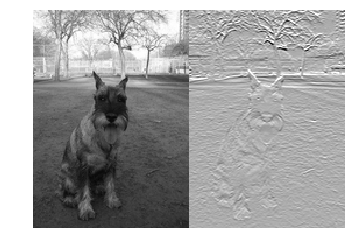

```python
horizontal_line_conv = [[1, 1],
                        [-1, -1]]
# load_my_image and visualize_conv are utility functions provided for this exercise
original_image = load_my_image()
visualize_conv(original_image, horizontal_line_conv)
```

Now it's your turn. Instead of a horizontal line detector, you will create a vertical line detector.

**Replace the underscores with numbers to make a vertical line detector and uncomment both lines of code in the cell below. Then run**

Correct

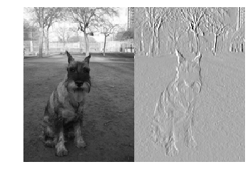

```python
vertical_line_conv = [[1, -1],
                      [1, -1]]

# Check your answer
q_1.check()
visualize_conv(original_image, vertical_line_conv)
```

If you'd like a hint or the solution, uncomment the appropriate line below.

```python
#q_1.hint()
#q_1.solution()
```

### Exercise 2

The convolutions you've seen are 2x2. But you could have larger convolutions. They could be 3x3, 4x4, etc. They don't even have to be square. Nothing prevents using a 4x7 convolution.

Compare the number of visual patterns that can be captured by small convolutions. Which of the following is true?

- There are more visual patterns that can be captured by large convolutions
- There are fewer visual patterns that can be captured by large convolutions
- The number of visual patterns that can be captured by large convolutions is the same as the number of visual patterns that can be captured by small convolutions?

Once you think you know the answer, check it by uncommenting and running the line below.

```python
# Check your answer (Run this code cell to receive credit!)
q_2.solution()
```

Solution: While any one convolution measures only a single pattern, there are more possible convolutions that can be created with large sizes. So there are also more patterns that can be captured with large convolutions.

For example, it's possible to create a 3x3 convolution that filters for bright pixels with a dark one in the middle. There is no configuration of a 2x2 convolution that would capture this.

On the other hand, anything that can be captured by a 2x2 convolution could also be captured by a 3x3 convolution.

Does this mean powerful models require extremely large convolutions? Not necessarily. In the next lesson, you will see how deep learning models put together many convolutions to capture complex patterns... including patterns to complex to be captured by any single convolution.

# Keep Going

Now you are ready to **[combine convolutions into powerful models](https://www.kaggle.com/dansbecker/building-models-from-convolutions).** These models are fun to work with, so keep going.

**[Deep Learning Home Page](https://www.kaggle.com/learn/deep-learning)**

*Have questions or comments? Visit the [Learn Discussion forum](https://www.kaggle.com/learn-forum) to chat with other Learners.*